# Bondora Credit Allocation Study

Progress Meeting 3

Group 7

Jheronimus Academy of Data Science

# How are Different Kinds of Credit Distributed among Bondora Borrowers?

## Background & Premise

- Bondora P2P Lending Service
- European dataset spanning between 2009-2021 with 179,000+ individual loans
- Data on 112 attributes of users individually and the characteristics of their loans

### Network Information

| **Type** $\mathrm{B}_1$ $\mathrm{B}_2$ | **Undirected Bipartite** Borrowers identified by `UserName` Reported `LoanUse` |
| --- | --- |
| **Edges** | $\mathrm{B}_1 \rightarrow \mathrm{B}_2:$ User takes out specific kind of loan $\mathrm{B}_2 \rightarrow \mathrm{B}_1:$ Specific loan type belongs to a User $\mathrm{B}_1 \nleftrightarrow \mathrm{B}_2:… |

## Theoretical Premise and RQs

- Overall Study
- Study 1
- LRQAP
- Study 2
- ERGM
- Traditional financial theory shows that investors exhibit behavioural biases in how they choose their investments (Aggarwal, 1981)
  - Behaviour varies based on risk attitudes and information theory
- Evidence shows that these same biases may also affect non-professional P2P borrowers (Herzenstein, Dholakia, & Andrews, 2011; Lee & Lee, 2012)
- Specifically, Ayal, Bar-Haim, & Ofir (2018) show that there is insufficient attention on borrowers’ portfolio formation
- We want to understand how non professional P2P borrowers form their portfolios and how this is affected by behavioural biases
- Investors’ familiarity with certain assets can make investments seem less risky, driving them towards it (Ayal et al., 2018)
- Galak, Small, & Stephen (2010) show clustering among borrowers and lenders across demographic attributes
- Amar, Ariely, Ayal, Cryder, & Rick (2011) show that borrowers are averse to holding *large number* of debts

  *Do borrowers vary in their loan use type and frequency based on their individual and loan characteristics?*
- Linear QAP can assess similarities across borrowers, taking into account loan frequency

Serrano-Cinca, Gutiérrez-Nieto, & López-Palacios (2015) show that heterogeneity in credit ratings explains significant differences across loan use purposes. Therefore:

**Hypothesis 1: Borrowers with the same credit ratings choose similar loan uses**

Ravina (2019) shows that occupation significant factor in whether loans are awarded. Ayal et al. (2018) suggests this can be generalised to reflect borrower preferences. Shared occupations can be indicative of similar preferences in loan use

**Hypothesis 2: Borrowers sharing the same occupation area tend to share loan uses**

- Individuals’ financial decisions are not independent (Kahneman & Tversky, 1979)
- Ayal et al. (2018) shows that these non-independent preferences can influence other borrowers
- Therefore, we investigate P2P behavioural biases from a structural perspective

*What behavioural mechanisms affect the structure of borrower-to-loan-use connections?*

Herzenstein et al. (2011) shows that familiarity bias can exhibit itself through clustering, or “relational herding”. Borrowers gravitate towards socially-validated or popular choices, resulting in overlapping decisions

**Hypothesis 3: Borrowers who share one loan purpose are likely to share another**

Theory of Perceived Diversification shows that borrowers’ distress increases with perceived distinctiveness of each loan type (Ayal & Zakay, 2009). Borrowers prefer to minimize this distress.

**Hypothesis 4: Borrowers exhibit preferences for minimal debt distinctiveness, selecting one loan use**

Cooper, Gorbachev, & Luengo‐Prado (2023) show that younger borrowers have fundamentally different credit use mix than older individuals due to how their access to credit shapes their consumption habits. Therefore:

**Hypothesis 5: Younger borrowers have different loan use mixes than older borrowers**

Aliano, Alnabulsi, Cestari, & Ragni (2023) show a significant gender effect on different loan uses and Croson & Gneezy (2009) explain this can be due to differences in risk perception and self-selection effects:

**Hypothesis 6: Gender differences lead to different loan use mixes**

## Summary of Hypotheses

- Study 1
- Study 2
- LR QAP modelling effect of shared attributes on the frequency and type of same loan use shared
- $Y=$ Weighted adjacency matrix of shared loan use

| Hypothesis | Expected Result | Specific Method |
| --- | --- | --- |
| H<sub>1</sub><sup>a</sup> : Borrowers with the same credit ratings choose similar loan uses | $\hat{\beta}_{1}>0$ | $X_1=$ Weighted adjacency matrix of shared credit rating |
| H<sub>2</sub><sup>a</sup> : Borrowers sharing the same occupation area tend to share loan uses | $\hat{\beta}_{2}>0$ | $X_2=$ Binary adjacency matrix of shared occupation area |
| - | - | $+$ $X_{2,3,..,n}=$ Controls |

- Studied using **Bipartite ERGMs** with binary edges

| Hypothesis | Expected Result | ERGM Term |
| --- | --- | --- |
| H<sub>3</sub><sup>a</sup> : Borrowers who share one loan purpose are likely to share another | $\hat{\theta}>0$ | `cycle(4)` |
| H<sub>4</sub><sup>a</sup> : Borrowers exhibit preferences for minimal debt distinctiveness, selecting one loan use | $\hat{\theta}>0$ | `b1degree(1)` |
| H<sub>5</sub><sup>a</sup> : Younger borrowers have different loan use mixes than older borrowers | $\hat{\theta}\neq0$ | `b1cov("b1_age")` |
| H<sub>6</sub><sup>a</sup> : Gender differences lead to different loan use mixes | $\hat{\theta}\neq0$ | `b1factor("gender")` |

## Data Preprocessing

- Procedures
- User Counts Plot
- Non-Network Descriptive Plots
- Select subset of 112 attributes

```r
keep_cols <- c("LoanId", "UserName","Age", "Gender",
               "Country", "Amount", "Interest","LoanDuration",
              "UseOfLoan", "Rating", "Restructured", "MonthlyPayment",
              "OccupationArea", "BiddingStartedOn")
```

- Remove any loans with `NA` for any of the above features
- Most complete data is between 2014-2016, when `UseofLoan` was reported (see user counts plot)
  - Filter `BiddingStartedOn` between these dates
- Preserve original connections by not filtering any further. Instead, randomly sample 500 individuals to narrow dataset down
- Create incidence matrix of $n \times m$, where $n$ is the unique borrowers and $m$ is the reported loan use to construct partitions $\mathrm{B}_1$ and $\mathrm{B}_2$

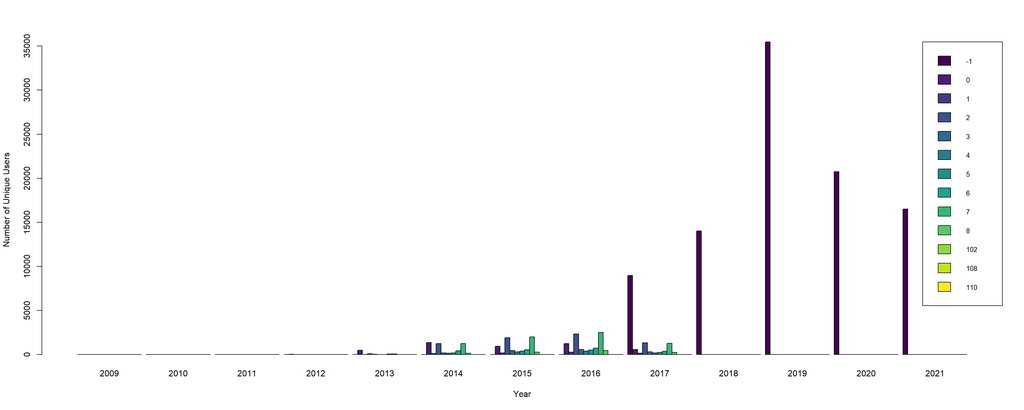

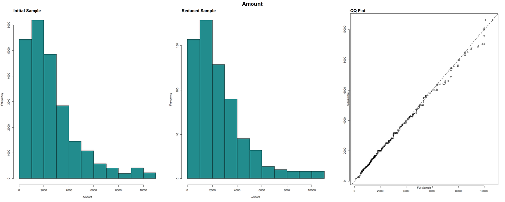

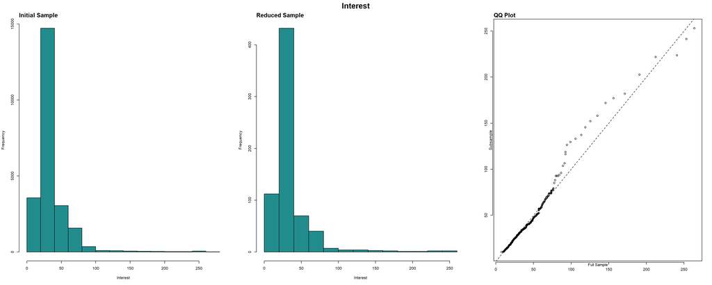

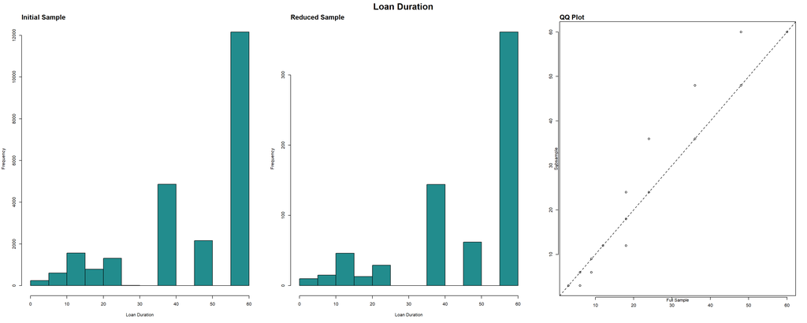

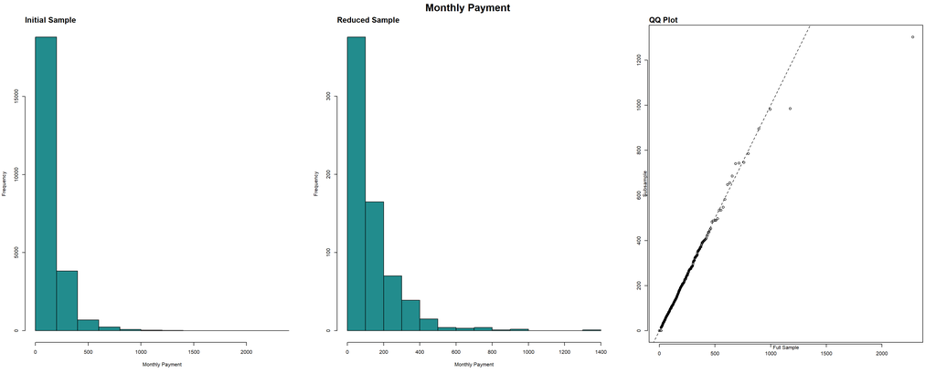

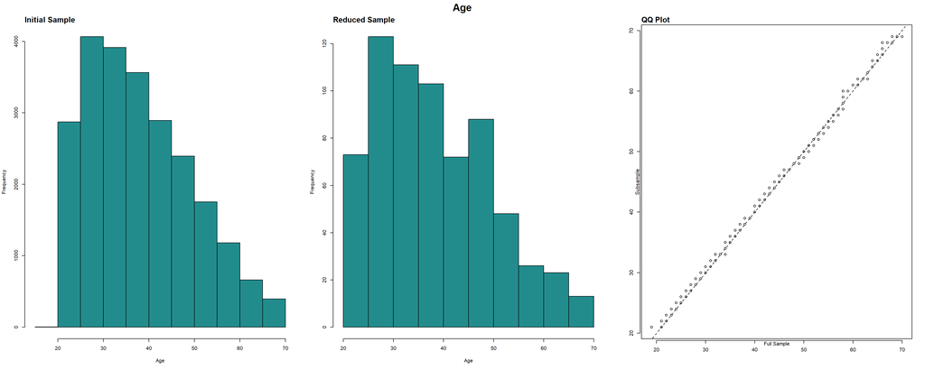

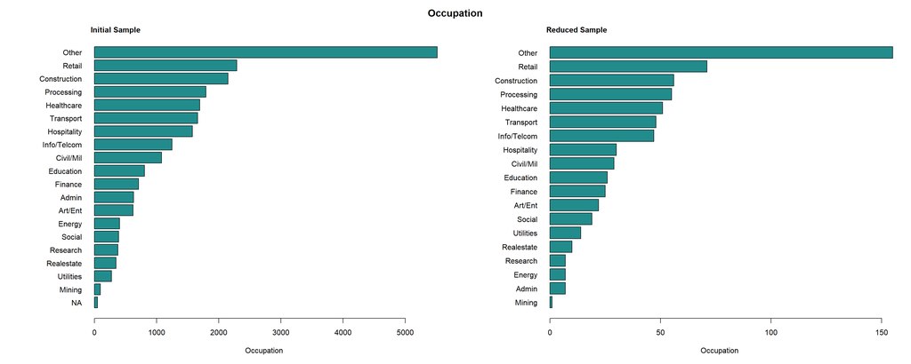

## Basic Network Statistics

- Network Visualisation
- Descriptive Statistics
- Descriptive Statistics Plot

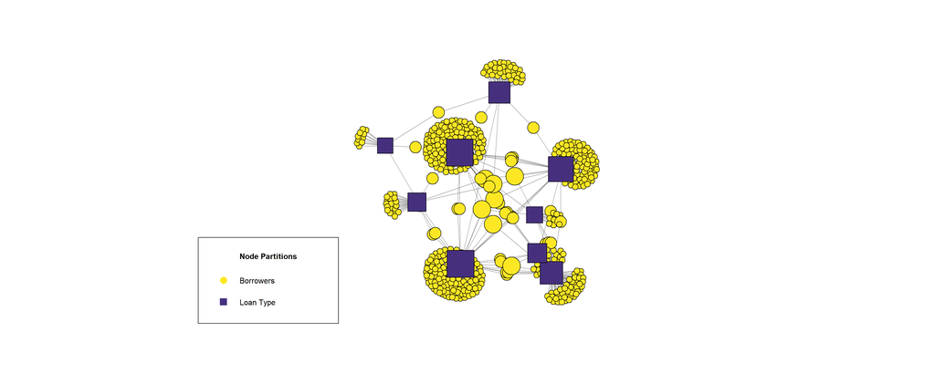

| Statistic | Measure |
| --- | --- |
| Vertex Count | 509.00 |
| Edge Count | 547.00 |
| Density | 0.12 |
| Centralization | 0.47 |
| Mean Distance | 3.66 |

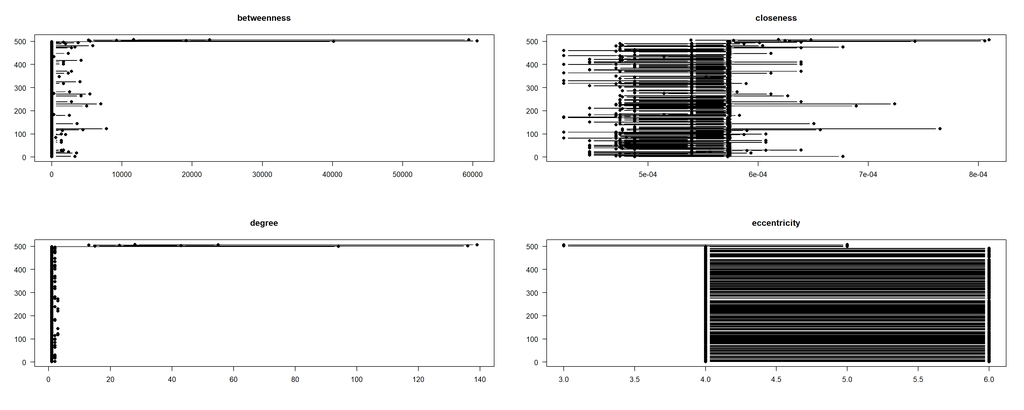

## Study 1 | QAP Results

- Notes
- Specification
- Results
- Estimates Plot
- Diagnostics
- Linear QAP Regression used to study how borrowers with the same loan type choice are affected by having the same credit rating
- The adjacency matrices used are **weighted** **by count** to give this study a level of detail we do not have with ERGM
  - Because the weights vary significantly, **standardised** results are more meaningful to compare
- Intercept has very significant impact: *not all effects can be accounted for and are missing*

```r
# Make function to run QAPs automatically
run_QAP <- function(y_mat, xlist, varnames, model_name) {

  # Run QAP Linear Regression
  model <- sna::netlm(y = y_mat, x = xlist, nullhyp = "qapspp", reps = 1000)
  model$names <- varnames
  summary(model)

  # Obtain results from Model and Name them
  results <- model$coefficients
  names(results) <- varnames

  # Add significance stars to model results
  results_sig <- paste(round(results,3), t_to_stars(model$tstat))

  # Save Model
  saveRDS(model, here::here("resources","objects","qap",
                            paste0(model_name,".Rds")))

  # Prepare function output
  list_names <- c("model","results","results_sig")
  items <- list(model, results, results_sig)
  names(items) <- list_names

  return(items)
}

# -----------------------------------------------------------------------------#

# Basic QAP Linear Regression 1 - Unstandardised + No Controls
qap_m1 <- run_QAP(loan_use_mat, main_pred_vars, main_pred_names, "qap_m1")

# Basic QAP Linear Regression 1 - Standardised + No Controls
scaled_dep <- scale(loan_use_mat)
scaled_pred <- lapply(main_pred_vars, scale)

qap_m2 <- run_QAP(scaled_dep, scaled_pred, main_pred_names, "qap_m2")

# Basic QAP Linear Regression 2 - Unstandardised + Controls
qap_m3 <- run_QAP(loan_use_mat, all_pred_vars, var_names, "qap_m3")

# Basic QAP Linear Regression 2 - Standardised + Controls
scaled_pred_2 <- lapply(all_pred_vars, scale)

qap_m4 <- run_QAP(scaled_dep, scaled_pred_2, var_names, "qap_m4")
```

[output not shown]

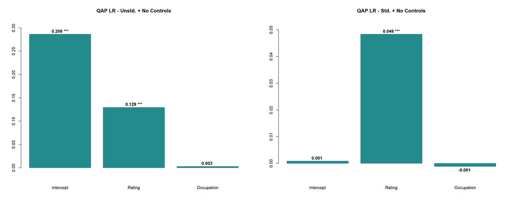

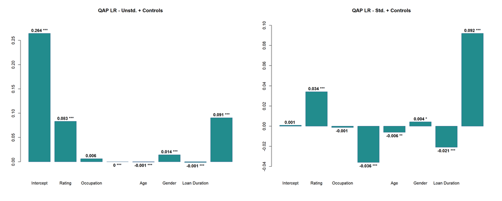

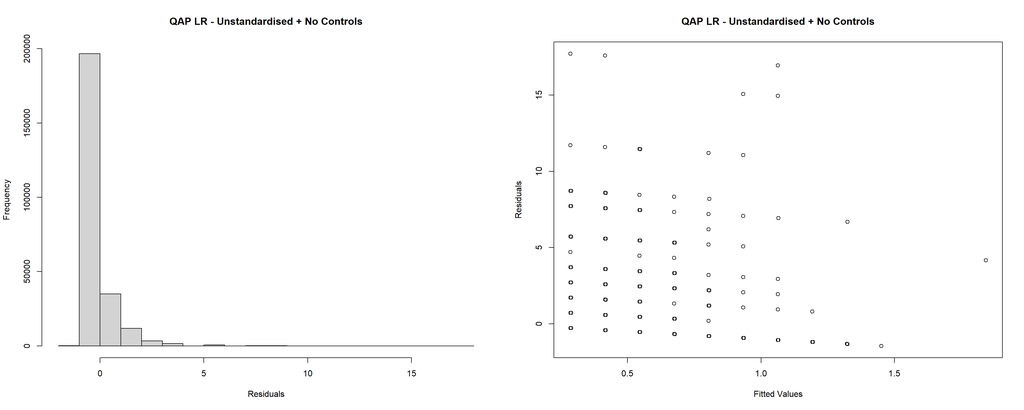

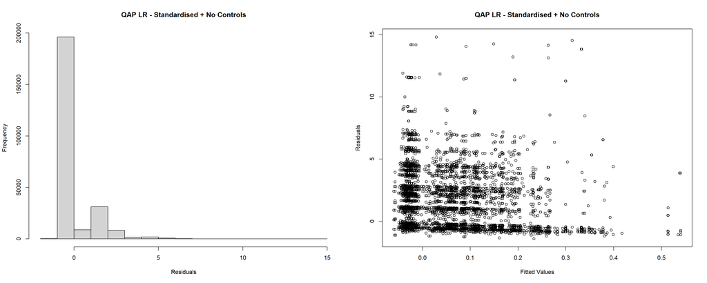

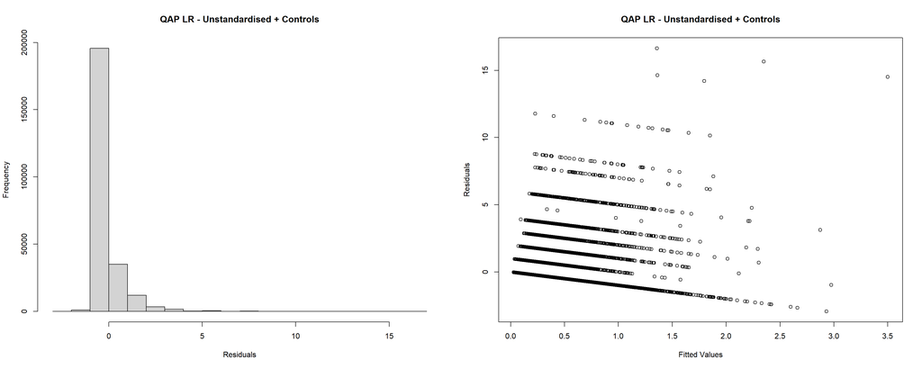

[figure not shown]

## Study 2 | ERGM | `edges`

- Summary
- Specification
- GOF
- Significant negative coefficient indicates large amount of sparsity
- Low SE
- Loan use mix is likely not random
- $\Rightarrow$ Base ERGM model looks as expected

```r
# Base Model + GOF
formula_base_model <- bondora_net ~ edges
base_ergm <- ergm::ergm(formula_base_model)
```

```
============================
                Model 1
----------------------------
edges              -1.98 ***
                   (0.05)
----------------------------
AIC              3325.83
BIC              3332.24
Log Likelihood  -1661.91
============================
*** p < 0.001; ** p < 0.01; * p < 0.05
```

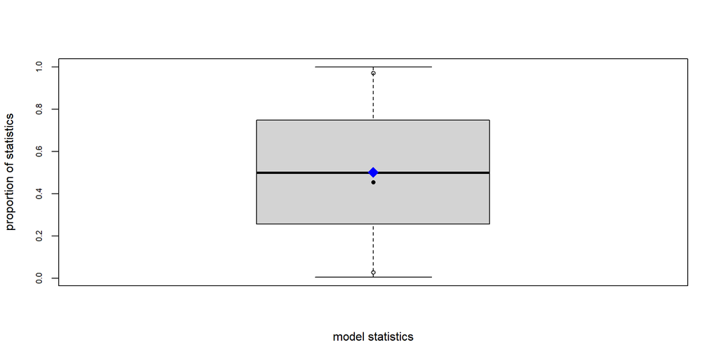

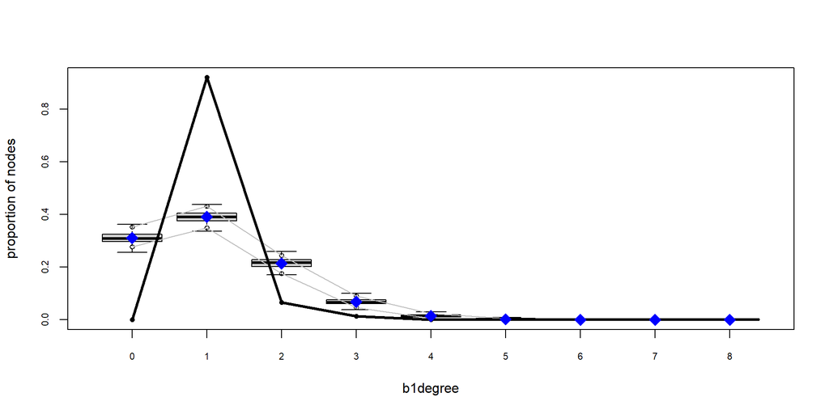

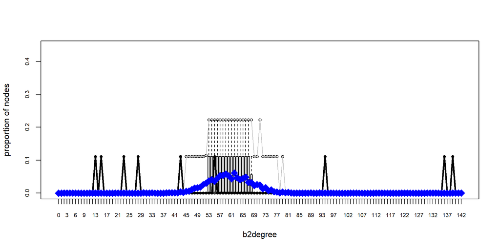

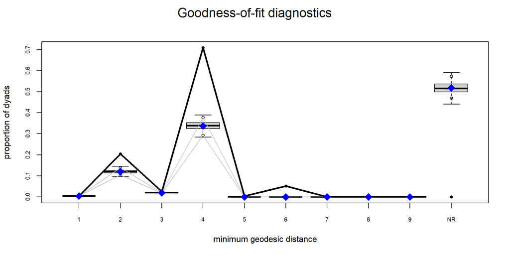

## Study 2 | ERGM | `b1degree(1)`

- Summary
- Specification
- Results
- MCMC
- GOF

**Modelling Notes**

- Quick convergence within 5-10 iterations

**Results**

```r
# Iteration 1 + MCMC Diagnostics + GOF
model_1_params <- bondora_net ~ edges +
  # See if individuals tend to pick one loan type
  b1degree(1)

model_1 <- ergm::ergm(
  model_1_params,
  #constraints = ~ bd(minout = 0, maxout = 80),

  control = ergm::control.ergm(
    # Greater burn-in for cleaner result
    MCMC.burnin = 20000,
    # Greater sample size for greater stability
    MCMC.samplesize = 100000,
    seed = 42,
    MCMC.interval = 1000,
    # Only needed for convergence pvals to improve
    MCMLE.maxit = 45,
    # Smaller steps for stability
    MCMLE.steplength = 0.25,
    parallel = n_cores,
    parallel.type = "PSOCK"
  )
)
```

```
==========================================
                Model 1       Model 2
------------------------------------------
edges              -1.98 ***     -1.35 ***
                   (0.05)        (0.12)
b1degree1                         3.31 ***
                                 (0.22)
------------------------------------------
AIC              3325.83       2674.44
BIC              3332.24       2687.26
Log Likelihood  -1661.91      -1335.22
==========================================
*** p < 0.001; ** p < 0.01; * p < 0.05
```

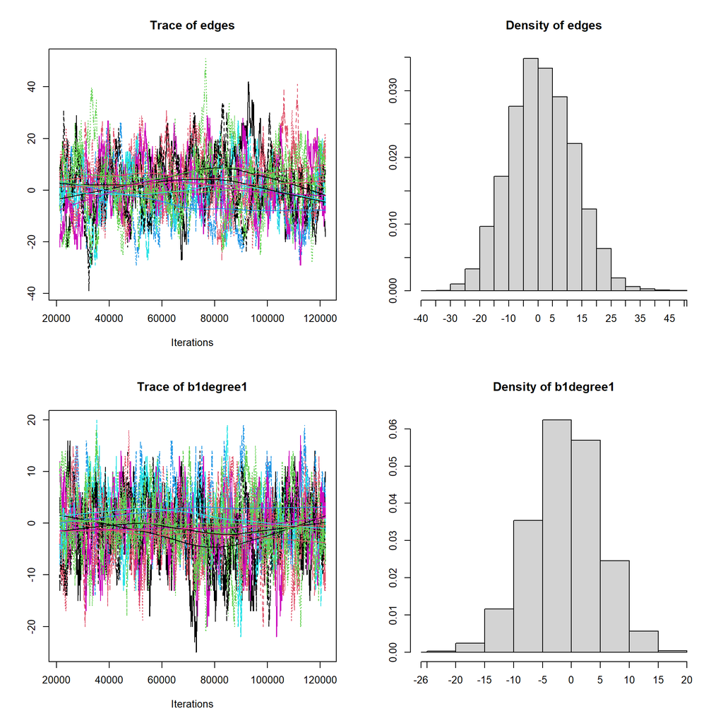

```
Sample statistics summary:

Iterations = 21136:121992
Thinning interval = 28
Number of chains = 9
Sample size per chain = 3603

1. Empirical mean and standard deviation for each variable,
   plus standard error of the mean:

            Mean     SD Naive SE Time-series SE
edges      1.727 11.066  0.06145         0.6592
b1degree1 -0.554  6.039  0.03353         0.2513

2. Quantiles for each variable:

          2.5% 25% 50% 75% 97.5%
edges      -19  -6   1   9    24
b1degree1  -13  -4   0   3    11


Are sample statistics significantly different from observed?
                 edges   b1degree1     (Omni)
diff.      1.726955932 -0.55404447         NA
test stat. 2.577412722 -2.16661869 5.80269221
P-val.     0.009954302  0.03026394 0.05651482

Sample statistics cross-correlations:
               edges  b1degree1
edges      1.0000000 -0.6736048
b1degree1 -0.6736048  1.0000000

Sample statistics auto-correlation:
Chain 1
            edges b1degree1
Lag 0   1.0000000 1.0000000
Lag 28  0.9826388 0.9701176
Lag 56  0.9664557 0.9439196
Lag 84  0.9498574 0.9180981
Lag 112 0.9335225 0.8938654
```

[output cut: 172 more lines]

```
    edges b1degree1
0.2384305 0.8167281
Joint P-value (lower = worse):  0.4940679

Note: To save space, only one in every 7 iterations of the MCMC sample
  used for estimation was stored for diagnostics. Sample size per chain
  was originally around 25221 with thinning interval 4.

Note: MCMC diagnostics shown here are from the last round of
  simulation, prior to computation of final parameter estimates.
  Because the final estimates are refinements of those used for this
  simulation run, these diagnostics may understate model performance.
  To directly assess the performance of the final model on in-model
  statistics, please use the GOF command: gof(ergmFitObject,
  GOF=~model).
```

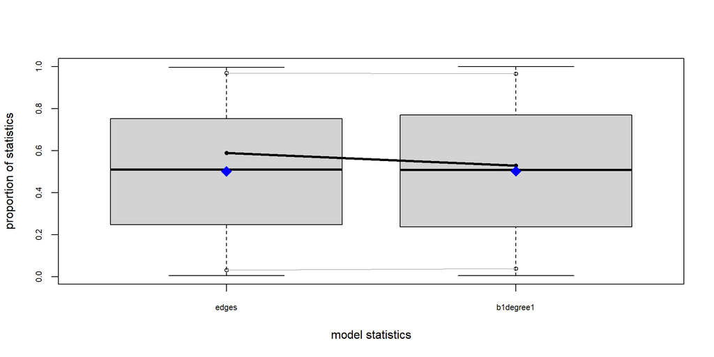

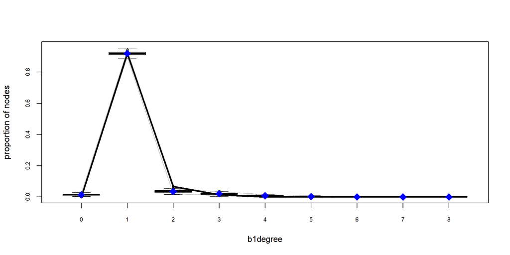

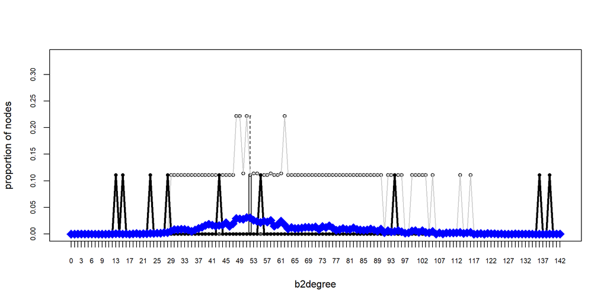

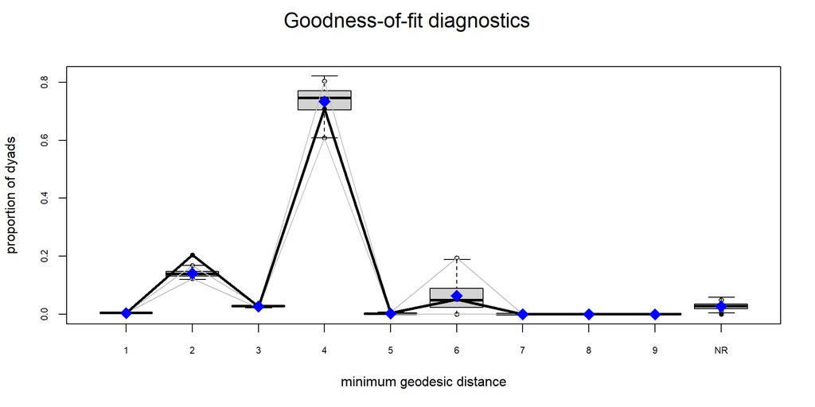

## Study 2 | ERGM | `cycle(4)`

- Summary
- Specification
- Results
- MCMC
- GOF

**Modelling Notes**

- Quick convergence within 5-10 iterations

**Results**

[output not shown]

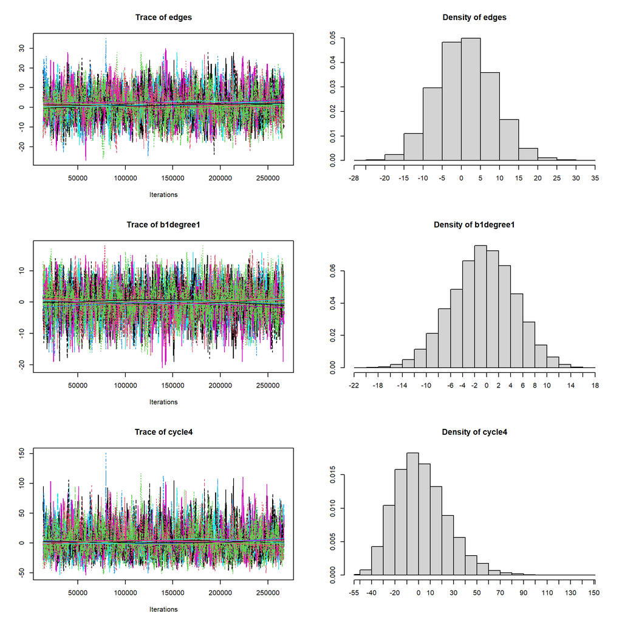

```
Sample statistics summary:

Iterations = 13376:267072
Thinning interval = 64
Number of chains = 9
Sample size per chain = 3965

1. Empirical mean and standard deviation for each variable,
   plus standard error of the mean:

              Mean     SD Naive SE Time-series SE
edges      1.44649  7.475  0.03957         0.1970
b1degree1 -0.05955  5.224  0.02766         0.1202
cycle4     3.02365 22.559  0.11942         0.5202

2. Quantiles for each variable:

          2.5% 25% 50% 75% 97.5%
edges      -13  -4   1   7    16
b1degree1  -10  -4   0   4    10
cycle4     -34 -13   1  17    53


Are sample statistics significantly different from observed?
                  edges   b1degree1       cycle4       (Omni)
diff.      1.446490e+00 -0.05954883 3.023651e+00           NA
test stat. 7.380226e+00 -0.49639643 5.879148e+00 8.382182e+01
P-val.     1.580205e-13  0.61961475 4.123823e-09 1.072914e-17

Sample statistics cross-correlations:
               edges b1degree1     cycle4
edges      1.0000000 -0.644952  0.8593833
b1degree1 -0.6449520  1.000000 -0.5739620
cycle4     0.8593833 -0.573962  1.0000000

Sample statistics auto-correlation:
Chain 1
            edges b1degree1    cycle4
Lag 0   1.0000000 1.0000000 1.0000000
Lag 64  0.9207720 0.8939305 0.8908135
```

[output cut: 175 more lines]

```
    edges b1degree1    cycle4
0.4684684 0.9162563 0.3972853
Joint P-value (lower = worse):  0.725172

Note: To save space, only one in every 4 iterations of the MCMC sample
  used for estimation was stored for diagnostics. Sample size per chain
  was originally around 15860 with thinning interval 16.

Note: MCMC diagnostics shown here are from the last round of
  simulation, prior to computation of final parameter estimates.
  Because the final estimates are refinements of those used for this
  simulation run, these diagnostics may understate model performance.
  To directly assess the performance of the final model on in-model
  statistics, please use the GOF command: gof(ergmFitObject,
  GOF=~model).
```

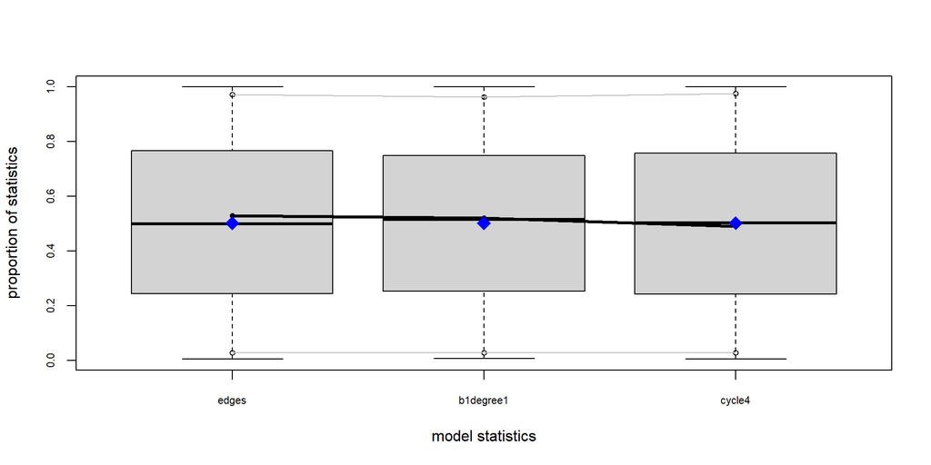

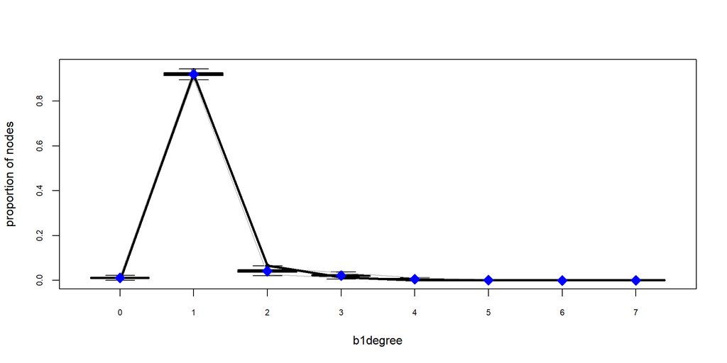

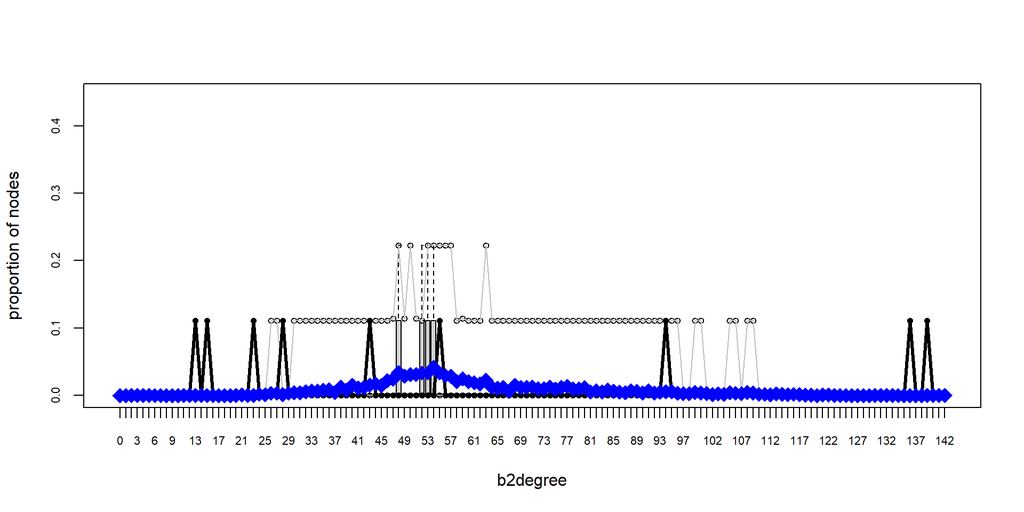

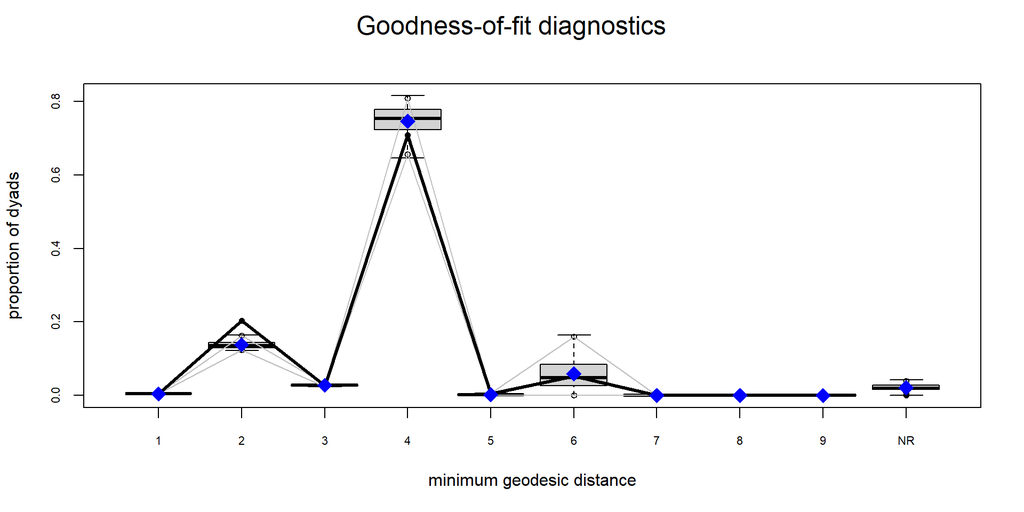

```r
# Iteration 2 + MCMC Diagnostics + GOF
model_2_params <- bondora_net ~ edges + b1degree(1) +
  # See if there is clustering around pairs of loan types
  cycle(4)

model_2 <- ergm::ergm(
  model_2_params,
  #constraints = ~ bd(minout = 0, maxout = 80),

  control = ergm::control.ergm(
    # Greater burn-in for cleaner result
    MCMC.burnin = 20000,
    # Greater sample size for greater stability
    MCMC.samplesize = 100000,
    seed = 42,
    MCMC.interval = 1000,
    # Only needed for convergence pvals to improve
    MCMLE.maxit = 45,
    # Smaller steps for stability
    MCMLE.steplength = 0.25,
    parallel = n_cores,
    parallel.type = "PSOCK"
    )
  )
```